# Proposal

Group4

11/19/2021

Group member: Suhui L, Jiaying J, Shuren H, Zihan Z

Github: https://github.com/zzh611/cryptocurrency

## Decription of dataset

This is a collection of 1 minute candlesticks of the top 1000 cryptocurrency pairs on Binance.com. We take ‘1INCH-BTC’ as an example to show you our dataset.

```r
data<-read_parquet("1INCH-BTC.parquet", as_tibble = TRUE)
colnames(data)
```

```
##  [1] "open"                         "high"
##  [3] "low"                          "close"
##  [5] "volume"                       "quote_asset_volume"
##  [7] "number_of_trades"             "taker_buy_base_asset_volume"
##  [9] "taker_buy_quote_asset_volume" "open_time"
```

## Explaination of variables

open&high&low&close: candlestick data of cryptocurrency pairs

volume: total trading amount of the first currency in the cryptocurrency pair

quote_asset_volume: total trading amount of the second currency in the cryptocurrency pair

number_of_trades: the number of cryptocurrency pair trades in the timeframe taker_buy_base_asset_volume: the amount of placed orders for the first currency in the cryptocurrency pair

taker_buy_quote_asset_volume: the amount of placed orders for the second currency in the cryptocurrency pair

open_time: the start time of recording

```r
data$maker_buy_base_asset_volumn <- data$volume - data$taker_buy_base_asset_volume
data$maker_buy_quote_asset_volumn <- data$quote_asset_volume - data$taker_buy_quote_asset_volume
data$ratio <- data$maker_buy_base_asset_volumn / data$maker_buy_quote_asset_volumn
```

## Summary of data

```r
summary(data)
```

```
##       open                high                low
##  Min.   :8.510e-06   Min.   :2.776e-05   Min.   :8.510e-06
##  1st Qu.:6.277e-05   1st Qu.:6.281e-05   1st Qu.:6.273e-05
##  Median :7.279e-05   Median :7.284e-05   Median :7.274e-05
##  Mean   :7.604e-05   Mean   :7.612e-05   Mean   :7.595e-05
##  3rd Qu.:8.736e-05   3rd Qu.:8.746e-05   3rd Qu.:8.726e-05
##  Max.   :1.670e-04   Max.   :1.680e-04   Max.   :1.659e-04
##
##      close               volume         quote_asset_volume number_of_trades
##  Min.   :2.768e-05   Min.   :     0.0   Min.   : 0.00000   Min.   :   0.00
##  1st Qu.:6.277e-05   1st Qu.:    49.6   1st Qu.: 0.00343   1st Qu.:   3.00
##  Median :7.279e-05   Median :   299.2   Median : 0.02191   Median :   7.00
##  Mean   :7.603e-05   Mean   :  1757.0   Mean   : 0.14029   Mean   :  16.77
##  3rd Qu.:8.737e-05   3rd Qu.:  1320.3   3rd Qu.: 0.09987   3rd Qu.:  16.00
##  Max.   :1.672e-04   Max.   :565528.6   Max.   :65.05942   Max.   :6643.00
##
##  taker_buy_base_asset_volume taker_buy_quote_asset_volume
##  Min.   :     0.0            Min.   : 0.00000
##  1st Qu.:     3.9            1st Qu.: 0.00028
##  Median :    82.8            Median : 0.00613
##  Mean   :   864.0            Mean   : 0.06896
##  3rd Qu.:   536.9            3rd Qu.: 0.04063
##  Max.   :424497.0            Max.   :50.85449
##
##    open_time                   maker_buy_base_asset_volumn
##  Min.   :2020-12-24 23:00:00   Min.   :     0.0
##  1st Qu.:2021-03-15 03:25:45   1st Qu.:     3.3
##  Median :2021-06-03 11:16:30   Median :    79.7
##  Mean   :2021-06-03 09:34:44   Mean   :   893.0
##  3rd Qu.:2021-08-22 16:23:15   3rd Qu.:   516.2
##  Max.   :2021-11-10 17:59:00   Max.   :391968.5
##
##  maker_buy_quote_asset_volumn     ratio
##  Min.   : 0.00000             Min.   : 6010
##  1st Qu.: 0.00024             1st Qu.:11029
##  Median : 0.00583             Median :13459
##  Mean   : 0.07133             Mean   :14103
##  3rd Qu.: 0.03899             3rd Qu.:15761
##  Max.   :40.41838             Max.   :36093
##                               NA's   :100636
```

## Plots

In this plot, “open_time” is the independent variable and 4 kinds of price (high, low, open, close) are dependent variables. This shows us the trend of each price from 2020-12-24 to 2021-11-10.

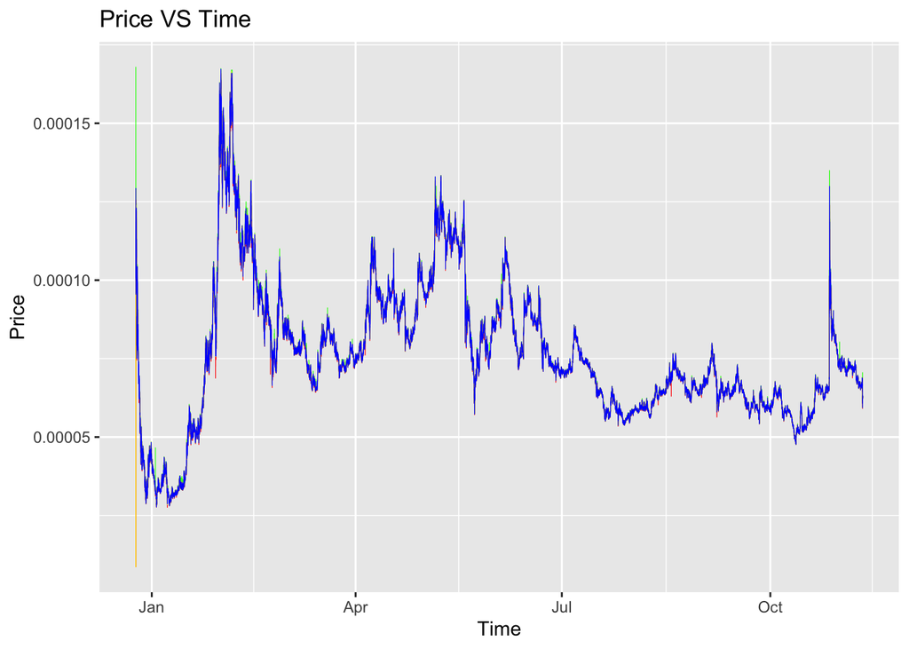

```r
library(ggplot2)
ggplot(data, aes(x=open_time)) +
  geom_line(aes(y=high),size=0.2, colour = "green") +
  geom_line(aes(y=low),size=0.2, colour = "red") +
  geom_line(aes(y=open),size=0.2, colour = "yellow") +
  geom_line(aes(y=close),size=0.2, colour = "blue") +
  ggtitle("Price VS Time") +
  ylab("Price") +
  xlab("Time")
```

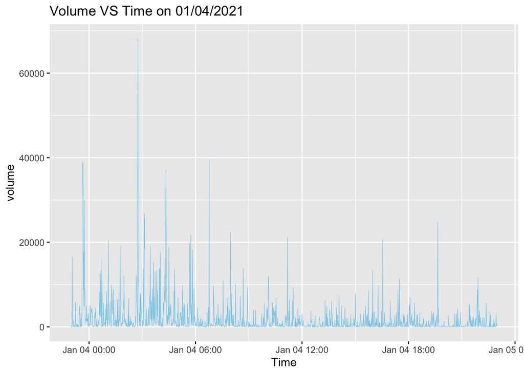

```r
vol <- data[c(14400:15840),]
ggplot(vol, aes(x=open_time)) +
  geom_line(aes(y=volume),size=0.2, colour = "skyblue") +
  ggtitle("Volume VS Time on 01/04/2021") +
  ylab("volume") +
  xlab("Time")
```

In this plot, “Ratio” is the independent variable and “Price” is the dependent variable. This shows us “Ratio” and “Price” are close to inversely proportional, which means that when “Price” goes up, the “Ratio” will go down.

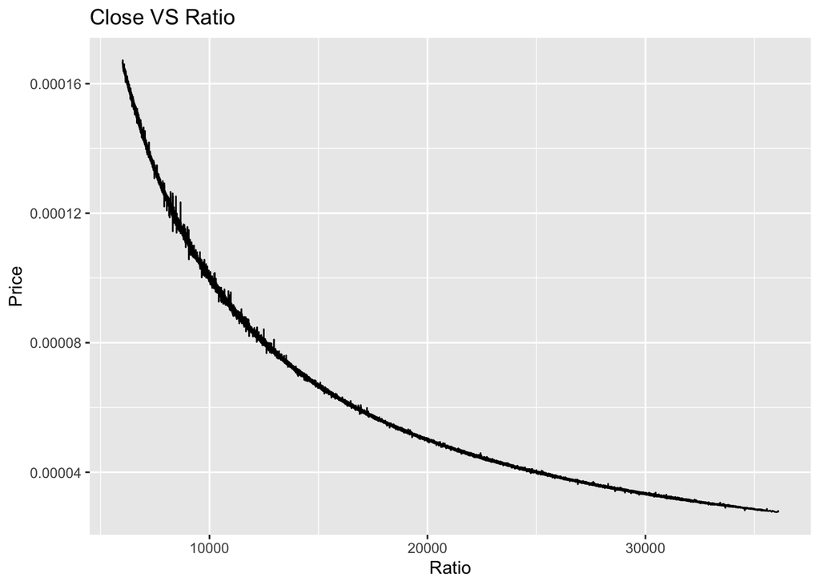

```r
library(ggplot2)
ggplot(data, aes(x=ratio, y=close)) +
  geom_line() +
  ggtitle("Close VS Ratio") +
  ylab("Price") +
  xlab("Ratio")
```

## Statistical methods

1. Predict the future trend of every trading pair base on several models, such as ARMA, ARIMA, GARCH, RNN, LSTM. Select the best model to fit this dataset.
2. Find the most strongly correlated cryptocurrency pairs for each cryptocurrency by comparing the variance and bias.

## Computational steps

1. Clean the raw data and make sure that the start and end of “open_time” is the same for each file
2. Use the statistical method and write a “job.sh” to deal with a single file
3. Distribute the job to 1000 files using “submit.sh” by HPC
4. Merge all the work together